# Coursera: Assignment of Practical Machine Learning

Shih

May 23, 2016

## Introduction

This is the assignment for Coursera Data Science: Practical Machine Learning. The purpose of the assignment is to predict the manner in which tester did the exercise. According to the instruction, the data set were collected by using movement-tracking devices which monitor activity of human bodies during exercise. In this assignment, prediction models were built from the movement data set and used to predict correct and incorrect barbell liftings.

## Materials

(Cited from the instruction of assignment)

### Background

Using devices such as Jawbone Up, Nike FuelBand, and Fitbit it is now possible to collect a large amount of data about personal activity relatively inexpensively. These type of devices are part of the quantified self movement – a group of enthusiasts who take measurements about themselves regularly to improve their health, to find patterns in their behavior, or because they are tech geeks. One thing that people regularly do is quantify how much of a particular activity they do, but they rarely quantify how well they do it. In this project, your goal will be to use data from accelerometers on the belt, forearm, arm, and dumbell of 6 participants. They were asked to perform barbell lifts correctly and incorrectly in 5 different ways. More information is available from the website here: http://groupware.les.inf.puc-rio.br/har (see the section on the Weight Lifting Exercise Dataset).

### Data

The training data for this project are available here: https://d396qusza40orc.cloudfront.net/predmachlearn/pml-training.csv

The test data are available here: https://d396qusza40orc.cloudfront.net/predmachlearn/pml-testing.csv

## Design

In this assignment, my predictions were performed in decision tree and random forest with easy interpretation and a better prediction for non-linear data. Both outcomes were used for evaluation.

## Results

### Load training data:

```r
set.seed(12345)
nastring <- c("NA","#DIV/0!","")
training <- read.csv("./pml-training.csv", na.strings = nastring)
```

### Data preparation:

1. Data partition
2. Remove near-zero/zero data
3. Remove variables with significant amount of missing data

Make data partition for training and testing. 60% to training, 40% to testing

```r
library(caret)
inTrain <- createDataPartition(training$classe, p = 0.6, list = F)
mytraining <- training[inTrain, ]
mytesting <- training[-inTrain, ]

dim(mytraining)
```

```
## [1] 11776   160
```

```r
dim(mytesting)
```

```
## [1] 7846  160
```

160 variables were included in the data.

Remove near-zero/zero data. I used “nearZeroVar” to identified with default setting.

```r
nzv <- nearZeroVar(mytraining, saveMetrics = T)
mytraining.woNZV <- mytraining[ , grep("FALSE", nzv$nzv)]
mytesting.woNZV <- mytesting[ , grep("FALSE", nzv$nzv)]

dim(mytraining.woNZV)
```

```
## [1] 11776   132
```

```r
dim(mytesting.woNZV)
```

```
## [1] 7846  132
```

```r
mytraining.woNZV <- mytraining.woNZV[, -1]
na_percentage <- apply(is.na(mytraining.woNZV), 2, sum)/nrow(mytraining.woNZV)
mytraining2 <- mytraining.woNZV[, (na_percentage < 0.1)]
dim(mytraining2)
```

```
## [1] 11776    58
```

```r
mytesting.woNZV <- mytesting.woNZV[, -1]
mytesting2 <- mytesting.woNZV[, (na_percentage < 0.1)]
dim(mytesting2)
```

```
## [1] 7846   58
```

After data processing, only 58 variables were left in the data. Now it was ready for prediction.

### Prediction

I performed two prediction model: 1. Decision Tree 2. Random Forest Model

#### Fit Decision Tree

```r
library(rpart)
library(rpart.plot)
library(rattle)
modFit.rpart <- rpart(classe ~ ., data = mytraining2, method="class")
print(modFit.rpart)
```

```
## n= 11776
##
## node), split, n, loss, yval, (yprob)
##       * denotes terminal node
##
##  1) root 11776 8428 A (0.28 0.19 0.17 0.16 0.18)
##    2) cvtd_timestamp=02/12/2011 13:32,02/12/2011 13:33,02/12/2011 13:34,02/12/2011 14:56,02/12/2011 14:57,05/12/2011 11:23,05/12/2011 11:24,05/12/2011 14:22,05/12/2011 14:23,28/11/2011 14:13,28/11/2011 14:14,30/11/2011 17:10,30/11/2011 17:11 7508 4160 A (0.45 0.3 0.21 0.048 0)
##      4) cvtd_timestamp=02/12/2011 13:32,02/12/2011 13:33,02/12/2011 14:56,05/12/2011 11:23,05/12/2011 14:22,28/11/2011 14:13,30/11/2011 17:10 2355  205 A (0.91 0.087 0 0 0)
##        8) raw_timestamp_part_1< 1.322833e+09 1715    0 A (1 0 0 0 0) *
##        9) raw_timestamp_part_1>=1.322833e+09 640  205 A (0.68 0.32 0 0 0)
##         18) cvtd_timestamp=02/12/2011 14:56,05/12/2011 11:23,05/12/2011 14:22 427    0 A (1 0 0 0 0) *
##         19) cvtd_timestamp=02/12/2011 13:33 213    8 B (0.038 0.96 0 0 0) *
##      5) cvtd_timestamp=02/12/2011 13:34,02/12/2011 14:57,05/12/2011 11:24,05/12/2011 14:23,28/11/2011 14:14,30/11/2011 17:11 5153 3096 B (0.23 0.4 0.3 0.069 0)
##       10) magnet_dumbbell_z< -2.5 2503 1343 A (0.46 0.42 0.12 0.002 0)
##         20) raw_timestamp_part_1< 1.323095e+09 2227 1067 A (0.52 0.47 0.0076 0.0022 0)
##           40) magnet_dumbbell_x< -456.5 1202  291 A (0.76 0.23 0.0067 0.0042 0)
##             80) raw_timestamp_part_1< 1.323084e+09 1021  110 A (0.89 0.096 0.0069 0.0049 0) *
##             81) raw_timestamp_part_1>=1.323084e+09 181    1 B (0 0.99 0.0055 0 0) *
##           41) magnet_dumbbell_x>=-456.5 1025  258 B (0.24 0.75 0.0088 0 0)
##             82) num_window< 68.5 172    0 A (1 0 0 0 0) *
##             83) num_window>=68.5 853   86 B (0.09 0.9 0.011 0 0) *
##         21) raw_timestamp_part_1>=1.323095e+09 276    0 C (0 0 1 0 0) *
##       11) magnet_dumbbell_z>=-2.5 2650 1403 C (0.014 0.38 0.47 0.13 0)
##         22) magnet_dumbbell_x>=-465.5 817  202 B (0.0061 0.75 0.12 0.12 0) *
##         23) magnet_dumbbell_x< -465.5 1833  687 C (0.018 0.22 0.63 0.14 0)
##           46) pitch_belt< -43.25 155   18 B (0 0.88 0.12 0 0) *
##           47) pitch_belt>=-43.25 1678  550 C (0.02 0.15 0.67 0.15 0)
##             94) magnet_belt_y>=554.5 1593  465 C (0.021 0.16 0.71 0.11 0) *
##             95) magnet_belt_y< 554.5 85    0 D (0 0 0 1 0) *
##    3) cvtd_timestamp=02/12/2011 13:35,02/12/2011 14:58,02/12/2011 14:59,05/12/2011 11:25,05/12/2011 14:24,28/11/2011 14:15,30/11/2011 17:12 4268 2103 E (0 0.004 0.12 0.37 0.51)
##      6) roll_belt< 125.5 3146 1590 D (0 0.0054 0.16 0.49 0.34)
##       12) roll_dumbbell< -66.33551 624  143 C (0 0.0064 0.77 0.085 0.14) *
##       13) roll_dumbbell>=-66.33551 2522 1019 D (0 0.0052 0.013 0.6 0.39)
##         26) accel_forearm_x< -83.5 1517  282 D (0 0.0086 0.011 0.81 0.17)
##           52) magnet_belt_y>=578.5 1358  145 D (0 0.0096 0.013 0.89 0.085) *
##           53) magnet_belt_y< 578.5 159   22 E (0 0 0 0.14 0.86) *
##         27) accel_forearm_x>=-83.5 1005  284 E (0 0 0.016 0.27 0.72)
##           54) accel_dumbbell_y< 48.5 389  157 D (0 0 0.041 0.6 0.36) *
##           55) accel_dumbbell_y>=48.5 616   36 E (0 0 0 0.058 0.94) *
##      7) roll_belt>=125.5 1122   16 E (0 0 0 0.014 0.99) *
```

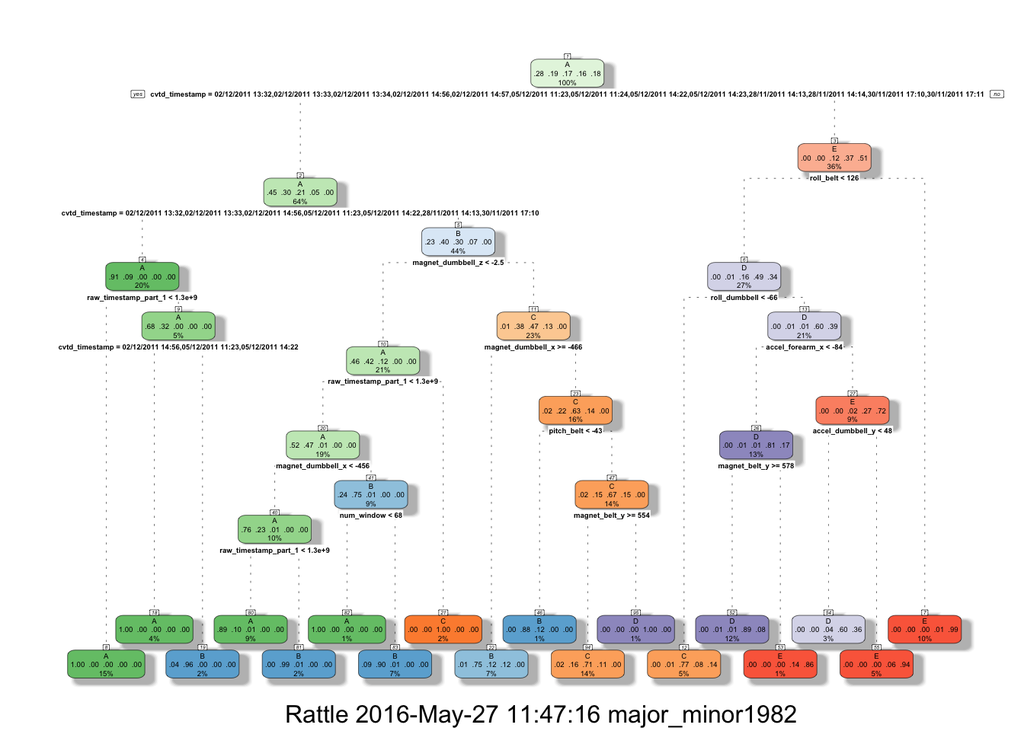

```r
fancyRpartPlot(modFit.rpart)
```

```r
predictions.rpart <- predict(modFit.rpart, newdata = mytesting2[, -58],
                         type = "class")

CM.rpart <- confusionMatrix(predictions.rpart, mytesting2$classe)
print(CM.rpart)
```

```
## Confusion Matrix and Statistics
##
##           Reference
## Prediction    A    B    C    D    E
##          A 2151   58   10    1    0
##          B   60 1270   80   58    0
##          C   21  180 1251  132   54
##          D    0   10   27 1032  185
##          E    0    0    0   63 1203
##
## Overall Statistics
##
##                Accuracy : 0.8803
##                  95% CI : (0.8729, 0.8874)
##     No Information Rate : 0.2845
##     P-Value [Acc > NIR] : < 2.2e-16
##
##                   Kappa : 0.8487
##  Mcnemar's Test P-Value : NA
##
## Statistics by Class:
##
##                      Class: A Class: B Class: C Class: D Class: E
## Sensitivity            0.9637   0.8366   0.9145   0.8025   0.8343
## Specificity            0.9877   0.9687   0.9403   0.9662   0.9902
## Pos Pred Value         0.9689   0.8651   0.7637   0.8230   0.9502
## Neg Pred Value         0.9856   0.9611   0.9812   0.9615   0.9637
## Prevalence             0.2845   0.1935   0.1744   0.1639   0.1838
## Detection Rate         0.2742   0.1619   0.1594   0.1315   0.1533
## Detection Prevalence   0.2829   0.1871   0.2088   0.1598   0.1614
## Balanced Accuracy      0.9757   0.9027   0.9274   0.8843   0.9122
```

#### Fit Random Forest Model

```r
modFit.rf <- randomForest(classe ~. ,
                          data = mytraining2,
                          trControl = trainControl(method = "cv"),
                          ntree = 10)
modFit.rf
```

```
##
## Call:
##  randomForest(formula = classe ~ ., data = mytraining2, trControl = trainControl(method = "cv"),      ntree = 10)
##                Type of random forest: classification
##                      Number of trees: 10
## No. of variables tried at each split: 7
##
##         OOB estimate of  error rate: 1.81%
## Confusion matrix:
##      A    B    C    D    E class.error
## A 3290   13    1    2    2 0.005441354
## B   23 2187   30    3    1 0.025401070
## C    4   27 1974   23    2 0.027586207
## D    1    2   24 1863   17 0.023072889
## E    4    6    2   24 2104 0.016822430
```

The out-of-sample (out-of-bag) error estimate was 1.81%. The confusion matrix is shown with the error estimates.

```r
predictions.rf <- predict(modFit.rf, mytesting2, type = "class")
CM.rf <- confusionMatrix(predictions.rf, mytesting2$classe)
print(CM.rf)
```

```
## Confusion Matrix and Statistics
##
##           Reference
## Prediction    A    B    C    D    E
##          A 2231    3    0    0    0
##          B    1 1513    8    0    0
##          C    0    2 1357    2    0
##          D    0    0    3 1280    6
##          E    0    0    0    4 1436
##
## Overall Statistics
##
##                Accuracy : 0.9963
##                  95% CI : (0.9947, 0.9975)
##     No Information Rate : 0.2845
##     P-Value [Acc > NIR] : < 2.2e-16
##
##                   Kappa : 0.9953
##  Mcnemar's Test P-Value : NA
##
## Statistics by Class:
##
##                      Class: A Class: B Class: C Class: D Class: E
## Sensitivity            0.9996   0.9967   0.9920   0.9953   0.9958
## Specificity            0.9995   0.9986   0.9994   0.9986   0.9994
## Pos Pred Value         0.9987   0.9941   0.9971   0.9930   0.9972
## Neg Pred Value         0.9998   0.9992   0.9983   0.9991   0.9991
## Prevalence             0.2845   0.1935   0.1744   0.1639   0.1838
## Detection Rate         0.2843   0.1928   0.1730   0.1631   0.1830
## Detection Prevalence   0.2847   0.1940   0.1735   0.1643   0.1835
## Balanced Accuracy      0.9995   0.9976   0.9957   0.9970   0.9976
```

The accuracy of Random Forest Model (0.9963038) is higher than which of Decision Tree (0.8803212). Random Forest was used for testing data.

### Testing data prediction

Load testing data

```r
testing <- read.csv("pml-testing.csv", na.strings=nastring)
dim(testing)
```

```
## [1]  20 160
```

Pick up variables used previously for prediction models

```r
name.mytr <- names(mytraining2) # col: 58
name.testing <- names(testing) # col: 160

same.variable <- intersect(name.testing, name.mytr) #same variable

testing <- testing[, same.variable]
dim(testing)
```

```
## [1] 20 57
```

Make levels of each variables in the testing data consistent with training data

```r
for (i in 1: length(testing)){
        levels(testing[, i]) <- levels(mytraining2[, i])
}
```

Predict with models built with Random Forest

```r
predictions.rf.test <- predict(modFit.rf, testing, type = "class")
print(predictions.rf.test)
```

```
##  1  2  3  4  5  6  7  8  9 10 11 12 13 14 15 16 17 18 19 20
##  B  A  B  A  A  E  D  B  A  A  B  C  B  A  E  E  E  B  B  B
## Levels: A B C D E
```